## Notas de aula de Mecânica Quântica Autor: Jonas Maziero

```python
%run init.ipynb
```

# Operador densidade e entropia

Este texto é baseado em https://arxiv.org/abs/1502.04489.

# O operador densidade

Vimos que o significado de dizermos que um sistema quântico foi preparado em um determinado estado $|\psi\rangle$ é que sabemos que um observável foi medido e que se obteve o autovalor correspondente a este autovetor. Vamos supor que temos somente informação parcial sobre a preparação do sistema. Ou seja, considere que sabemos que o sistema foi preparado no estado $|\psi_{j}\rangle$ com probabilidade $p_{j}$, com $j=1,\cdots,n$, mas para cada quanton que nos é apresentado não sabemos qual é o valor de $j$, i.e., o índice $j$ é uma variável aleatória. Como podemos calcular probabilidades de medidas futuras de um observável $O$? Bom, para cada medida que faremos de $O$, o sistema estará definitivamente em um dos estados $\{|\psi_{j}\rangle\}_{j=1}^{n}$. Então, para o conjunto de quantons no estado $|\psi_{j}\rangle$, segue valendo a regra de Born: \begin{equation} Pr(o|\psi_{j}) = |\langle\psi_{j}|o\rangle|^{2}. \end{equation} Para obter a probabilidade para todo o ensemble $\{|\psi_{j}\rangle,p_{j}\}_{j=1}^{n}$ consideramos a média dessas probabilidades (se o índice $j$ é uma variável aleatória, a função $Pr(o|\psi_{j})$ também é): \begin{align} Pr(o|\{p_{j},|\psi_{j}\rangle\}) & = \sum_{j=1}^{n} Pr(o|\psi_{j})p_{j} \\ & = \sum_{j=1}^{n}|\langle o|\psi_{j}\rangle|^{2}p_{j} \\ & = \sum_{j=1}^{n} \langle o|\psi_{j}\rangle\langle\psi_{j}|o\rangle p_{j} \\ & = \langle o|\sum_{j=1}^{n} p_{j}|\psi_{j}\rangle\langle\psi_{j}|o\rangle \\ & =: \langle o|\rho|o\rangle \\ & \equiv Pr(o|\rho), \end{align} onde definimos o chamado **operador densidade** como \begin{equation} \rho := \sum_{j=1}^{n} p_{j}|\psi_{j}\rangle\langle\psi_{j}|. \end{equation} *OBS:* Os estados $\{|\psi_{j}\rangle\}_{j=1}^{n}$ não precisam ser mutuamente ortogonais. Ademais, $n$ pode ser menor, igual ou maior que a dimensão do espaço de estados do sistema $d=\dim\mathcal{H}$.

*OBS:* Podem existir vários ensembles $\{|\psi_{j}\rangle,p_{j}\}_{j=1}^{n}$ diferentes que nos levam ao mesmo operador densidade. Ou seja, há arbitrariedade quando fazemos o mapa $\rho\rightarrow\{|\psi_{j}\rangle,p_{j}\}_{j=1}^{n}$, embora o mapa $\{|\psi_{j}\rangle,p_{j}\}_{j=1}^{n}\rightarrow\rho$ seja único.

*OBS:* No contexto do operador densidade, temos dois tipos de incerteza, a "clássica", codificada nas probabilidades dos diferentes estados do ensemble, e a "quântica", devida ao fato de que estes estados, individualmente, podem ser superposições dos autovetores do observável a ser medido.

*OBS:* Repetibilidade continua sendo utilizada para identificar estados preparados.

A função traço é definida como $$\mathrm{Tr}(X)=\sum_{j}\langle b_{j}|X|b_{j}\rangle,$$ com $\{|b_{j}\rangle\}_{j=1}^{d}$ sendo qualquer base ortonormal do espaço de Hilbert sendo considerado. Sem perda de generalidade, considerando uma base $\{|b_{j}\rangle\}_{j=1}^{d}$ tal que $|b_{1}\rangle=|o\rangle$, podemos verificar que \begin{align} \mathrm{Tr}(\rho\Pi_{o}) & := \mathrm{Tr}(\rho|o\rangle\langle o|) \\ & = \sum_{j=1}^{d}\langle b_{j}|\rho|o\rangle\langle o|b_{j}\rangle \\ & = \sum_{j=1}^{d}\langle b_{j}|\rho|o\rangle\delta_{1j} \\ & = \langle o|\rho|o\rangle \\ & = Pr(o|\rho). \end{align} Além disso, como você verificará, pode-se escrever $$\langle O\rangle_{\rho} = \mathrm{Tr}(\rho O).$$

### Exemplo

Para partículas de spin 1/2, consideremos que alguém prepara $|z_{+}\rangle$ com probabilidade $p$ ou $|x_{+}\rangle$ com probabilidade $1-p$. O operador densidade associado a esse ensemble $\{(|z_{+}\rangle,p),(|z_{-}\rangle,1-p)\}$ será: \begin{align} \rho & = p|z_{+}\rangle\langle z_{+}| + (1-p)|x_{+}\rangle\langle x_{+}| \\ & = p|z_{+}\rangle\langle z_{+}| + 2^{-1}(1-p)(|z_{+}\rangle+|z_{-}\rangle)(\langle z_{+}|+\langle z_{-}|) \\ & = p|z_{+}\rangle\langle z_{+}| + 2^{-1}(1-p)(|z_{+}\rangle\langle z_{+}|+|z_{-}\rangle\langle z_{+}| + |z_{+}\rangle\langle z_{-}|+|z_{-}\rangle\langle z_{-}|) \\ & = 2^{-1}(1+p)|z_{+}\rangle\langle z_{+}| + 2^{-1}(1-p)|z_{-}\rangle\langle z_{-}| + 2^{-1}(1-p)(|z_{-}\rangle\langle z_{+}| + |z_{+}\rangle\langle z_{-}|) \\ & = \frac{1}{2}\begin{bmatrix} 1+p & 1-p \\ 1-p & 1-p \end{bmatrix}. \end{align} Acima usamos $|x_{\pm}\rangle = (|z_{+}\rangle \pm |z_{-}\rangle)/\sqrt{2}$.

Consideremos que o spin 1/2 é preparado no ensamble $\rho$ e que mediremos a componente do spin na direção $y$. Teremos as seguintes probabilidades. Usaremos $|y_{\pm}\rangle = (|z_{+}\rangle \pm i|z_{-}\rangle)/\sqrt{2}$ e $|y_{\pm}\rangle = ((1\pm i)/2)|x_{+}\rangle + ((1\mp i)/2)|x_{-}\rangle$. Começamos com \begin{align} Pr(y_{+}|\rho) &= pPr(y_{+}|z_{+})+(1-p)Pr(y_{+}|x_{+}) \\ & = p|\langle y_{+}|z_{+}\rangle|^{2}+(1-p)|\langle y_{+}|x_{+}\rangle|^{2} \\ & = p|1\sqrt{2}|^{2}+(1-p)|(1+i)/2|^{2} \\ & = p/2+(1-p)((1+i)(1-i)/4 \\ & = p/2 +(1-p)/2 \\ & = 1/2. \end{align}

Também podemos usar \begin{align} Pr(y_{+}|\rho) & = \langle y_{+}|\rho|y_{+}\rangle \\ & = |y_{+}\rangle^{\dagger}|\frac{1}{2}\begin{bmatrix} 1+p & 1-p \\ 1-p & 1-p \end{bmatrix}\frac{1}{\sqrt{2}}\begin{bmatrix} 1 \\ i \end{bmatrix} \\ & = \frac{1}{\sqrt{2}}\begin{bmatrix} 1 & -i \end{bmatrix}\frac{1}{2\sqrt{2}}\begin{bmatrix} 1+p+(1-p)i \\ (1-p)(1+i) \end{bmatrix} \\ & = \frac{1}{4}(1+p+(1-p)i +(1-p)(1-i)) \\ & = 1/2. \end{align}

Uma vez que \begin{equation} \Pi_{y_{+}} = |y_{+}\rangle\langle y_{+}| = \frac{1}{2} \begin{bmatrix} 1 \\ i \end{bmatrix}\begin{bmatrix} 1 & -i \end{bmatrix} = \frac{1}{2} \begin{bmatrix} 1 & -i \\ i & 1 \end{bmatrix}, \end{equation} podemos ainda usar \begin{align} Pr(y_{+}|\rho) & = Tr(\rho\Pi_{y_{+}}) \\ & = Tr\left(\frac{1}{2}\begin{bmatrix} 1+p & 1-p \\ 1-p & 1-p \end{bmatrix}\frac{1}{2} \begin{bmatrix} 1 & -i \\ i & 1 \end{bmatrix}\right) \\ & = Tr\left(\frac{1}{4}\begin{bmatrix} (1+p)+(1-p)i & -i(1+p)+(1-p) \\ (1-p)(1+i) & (1-p)(1-i) \end{bmatrix}\right) \\ & = 1/2. \end{align}

Por fim, \begin{equation} Pr(y_{-}|\rho) = 1-Pr(y_{+}|\rho)=1/2. \end{equation}

## Propriedades de $\rho$

Qualque operador densidade quântico válido deve possuir as seguintes propriedades:

- Traço igual a um:  
  \begin{align} \mathrm{Tr}(\rho) & = \sum_{j=1}^{n} p_{j}\mathrm{Tr}(|\psi_{j}\rangle\langle\psi_{j}|) \\ & = \sum_{j=1}^{n} p_{j} \\ & = 1. \end{align}
- Hermiticidade/Positividade:
  Primeiramente notemos que qualquer operador densidade é um operador Hermitiano: \begin{align} \rho^{\dagger} & = \left(\sum_{j=1}^{n} p_{j}|\psi_{j}\rangle\langle\psi_{j}|\right)^{\dagger} \\ & = \sum_{j=1}^{n} (p_{j})^{*}(|\psi_{j}\rangle\langle\psi_{j}|)^{\dagger} \\ & = \sum_{j=1}^{n} p_{j}|\psi_{j}\rangle\langle\psi_{j}| \\ & = \rho. \end{align} Então, podemos diagonalizar essa matriz: $$\rho := \sum_{j=1}^{d}r_{j}|r_{j}\rangle\langle r_{j}|.$$ Claro, podemos interpretar esse $\rho$ como representando o ensemble $$\rho\equiv \{|r_{j}\rangle,r_{j}\}_{j=1}^{d}.$$ Por isso os autovalores $r_{j}$ devem ser não negativos, além de $\sum_{j=1}^{d}r_{j}=1$. Garantimos positividade dos autovalores exigindo de forma geral que \begin{equation} \rho\ge \mathbb{O}. \end{equation}

## Equação de von Neumann (EvN)

Considere um sistema preparado no estado $$\rho_{0} = \sum_{j=1}^{d} p_{j}|\psi_{j}\rangle\langle\psi_{j}| \equiv \{|\psi_{j}\rangle,p_{j}\}_{j=1}^{d}.$$ Digamos que este sistema evolui por um tempo $t$ segundo o Hamiltoniano $H_{t}$. Qual será o operador densidade evoluído desse sistema? Da ideia de ensemble sabemos que é cada um dos estados $|\psi_{j}\rangle$ que evoluirá no tempo. Ou seja, no tempo $t$ teremos o novo ensemble $\{|\psi_{j}(t)\rangle,p_{j}\}_{j=1}^{d}$ com \begin{equation} |\psi_{j}(t)\rangle = U_{t}|\psi_{j}\rangle. \end{equation} Segue assim que \begin{align} \rho_{t} & = \sum_{j} p_{j}|\psi_{j}(t)\rangle\langle\psi_{j}(t)| \\ & = \sum_{j} p_{j}U_{t}|\psi_{j}\rangle\langle\psi_{j}|U_{t}^{\dagger} \\ & = U_{t}\sum_{j} p_{j}|\psi_{j}\rangle\langle\psi_{j}|U_{t}^{\dagger} \\ & = U_{t}\rho_{0} U_{t}^{\dagger}. \end{align}

Derivando essa equação em relação ao tempo e usando a eq. de Schrödinger, $i\hbar\partial_{t}U_{t} = H_{t}U_{t}$, obteremos a **equação de von Neumann**: \begin{align} i\hbar\partial_{t}\rho_{t} & = i\hbar(\partial_{t}U_{t})\rho U_{t}^{\dagger} + 0 + U_{t}\rho i\hbar\partial_{t}U_{t}^{\dagger} \\ & = H_{t}U_{t}\rho U_{t}^{\dagger} - U_{t}\rho U_{t}^{\dagger}H_{t} \\ & = H_{t}\rho_{t} - \rho_{t}H_{t} \\ & = [H_{t},\rho_{t}]. \end{align}

OBS. Note que aqui estamos usando a representação de Schrödinger.

### Exemplo

Consideremos o Hamiltoniano $H=-(\hbar\omega/2)\sigma_{z}$ e um estado inicial qualquer de um spin 1/2. Denotando $\rho_{jk}(t)\equiv\rho_{jk}$ teremos \begin{align} [H_{t},\rho_{t}] & = -\frac{\hbar\omega}{2}\left[\begin{bmatrix}1&0\\0&-1\end{bmatrix},\begin{bmatrix}\rho_{11}&\rho_{12}\\\rho_{21}&\rho_{22}\end{bmatrix}\right] \\ & = -\frac{\hbar\omega}{2}\left(\begin{bmatrix}1&0\\0&-1\end{bmatrix}\begin{bmatrix}\rho_{11}&\rho_{12}\\\rho_{21}&\rho_{22}\end{bmatrix} - \begin{bmatrix}\rho_{11}&\rho_{12}\\\rho_{21}&\rho_{22}\end{bmatrix}\begin{bmatrix}1&0\\0&-1\end{bmatrix}\right) \\ & = -\frac{\hbar\omega}{2}\left(\begin{bmatrix}\rho_{11}&\rho_{12}\\-\rho_{21}&-\rho_{22}\end{bmatrix} - \begin{bmatrix}\rho_{11}&-\rho_{12}\\ \rho_{21}&-\rho_{22}\end{bmatrix}\right) \\ & = -\frac{\hbar\omega}{2}\begin{bmatrix}0&2\rho_{12}\\-2\rho_{21}&0\end{bmatrix} \\ & = -\hbar\omega\begin{bmatrix}0&\rho_{12}\\-\rho_{21}&0\end{bmatrix}. \end{align} Assim \begin{equation} i\hbar\partial_{t}\rho_{t} = i\hbar\begin{bmatrix}\partial_{t}\rho_{11}&\partial_{t}\rho_{12}\\\partial_{t}\rho_{21}&\partial_{t}\rho_{22}\end{bmatrix}=-\hbar\omega\begin{bmatrix}0&\rho_{12}\\-\rho_{21}&0\end{bmatrix}, \end{equation} ou \begin{cases} \partial_{t}\rho_{11} = 0 \therefore \rho_{11}(t)=\rho_{11}(0), \\ \partial_{t}\rho_{12} = i\omega\rho_{12} \therefore \rho_{12}(t)=\rho_{12}(0)e^{i\omega t}, \\ \rho^{\dagger}=\rho\therefore \rho_{21}(t) = (\rho_{12}(t))^{*} = (\rho_{12}(0))^{*}e^{-i\omega t} = \rho_{21}(0)e^{-i\omega t}, \\ Tr(\rho_{t})=1\therefore \rho_{22}(t) = 1-\rho_{11}(t) = 1-\rho_{11}(0)=\rho_{22}(0). \end{cases} Então o estado evoluído lê-se: \begin{equation} \rho_{t} \doteq \begin{bmatrix}\rho_{11}(0)& \rho_{12}(0)e^{i\omega t} \\ \rho_{21}(0)e^{-i\omega t} & \rho_{22}(0)\end{bmatrix}. \end{equation}

### Exemplo: Representação de $\rho:\mathbb{C}^{2}\rightarrow\mathbb{C}^{2}$ em $\mathbb{R}^{3}$

As matrizes $\{\sigma_{j}/\sqrt{2}\}_{j=0}^{3}$ formam uma base ortonormal para $\mathbb{C}^{2x2}$, sob o produto interno de Hilbert-Schmidt $\langle A|B\rangle = \mathrm{Tr}(A^{\dagger}B)$. Por conseguinte, qualquer operador densidade pode ser escrito como \begin{align} \rho & = \sum_{j=0}^{3} \mathrm{Tr}\left(\rho\frac{\sigma_{j}}{\sqrt{2}}\right)\frac{\sigma_{j}}{\sqrt{2}} \\ & = \frac{1}{2}\sum_{j=0}^{3}\langle\sigma_{j}\rangle_{\rho}\sigma_{j} \\ & =: \frac{1}{2}\left(\sigma_{0} + \sum_{j=1}^{3}r_{j}\sigma_{j}\right) \\ & =\vdots \\ & = \frac{1}{2}\begin{bmatrix} 1+r_{3} & r_{1}-i r_{2} \\ r_{1}+i r_{2} & 1-r_{3} \end{bmatrix}, \end{align} em que usamos $$\langle\sigma_j\rangle_\rho = Tr(\sigma_j \rho)$$ e $$\langle\sigma_{0}\rangle_{\rho}=Tr(\rho\sigma_{0})=Tr(\rho)=1.$$

*OBS:* Os autovalores de $\rho$ são $(1\pm r)/2$, com $r = \sqrt{\sum_{j=1}^{3}r_{j}^{2}}$ e $r_{j}\in[-1,+1]$. Pela positividade do operador densidade, estados físicos estão dentro de uma bola de raio 1 em $\mathbb{R}^{3}$ centrada em (0,0,0). As componentes do ponto de $\mathbb{R}^{3}$ que representa $\rho$ são $(r_{1},r_{2},r_{3})$, que é chamado de *vetor de Bloch*.

Consideremos um spin 1/2 em um estado $\rho=\frac{1}{2}\left(\sigma_{0} + \sum_{j=1}^{3}r_{j}\sigma_{j}\right)$ e evoluindo sob o Hamiltoniano $H=-2^{-1}\hbar\omega\sigma_{3}$. Teremos assim que \begin{align} i\hbar\partial_{t}\rho_{t} & = [H_{t},\rho_{t}] \\ i\hbar\partial_{t}\frac{1}{2}\begin{bmatrix} 1+r_{3}(t) & r_{1}(t)-i r_{2}(t) \\ r_{1}(t)+i r_{2}(t) & 1-r_{3}(t) \end{bmatrix} & = [-2^{-1}\hbar\omega\sigma_{3},2^{-1}(\sigma_{0}+r_{1}(t)\sigma_{1}+r_{2}(t)\sigma_{2}+r_{3}(t)\sigma_{3})] \\ \frac{i\hbar}{2}\begin{bmatrix} 0+\partial_{t}r_{3}(t) & \partial_{t}r_{1}(t)-i \partial_{t}r_{2}(t) \\ \partial_{t}r_{1}(t)+i \partial_{t}r_{2}(t) & 0-\partial_{t}r_{3}(t) \end{bmatrix} & = -\frac{\hbar\omega}{4}[\sigma_{3},\sigma_{0}+r_{1}(t)\sigma_{1}+r_{2}(t)\sigma_{2}+r_{3}(t)\sigma_{3}] \\ & = -\frac{\hbar\omega}{4}\left(\mathbb{0} + r_{1}(t)2i\epsilon_{312}\sigma_{2}+ r_{2}(t)2i\epsilon_{321}\sigma_{1}+\mathbb{0}\right) \\ & = -\frac{i\hbar\omega}{2}\left(r_{1}(t)\sigma_{2} - r_{2}(t)\sigma_{1}\right) \\ & = \frac{i\hbar\omega}{2}\begin{bmatrix} 0 & r_{2}(t)-ir_{1}(t) \\ r_{2}(t)+ir_{1}(t) & 0 \end{bmatrix} \end{align}

Primeiro observe que $$\partial_{t}r_{3}(t) = 0 \Rightarrow r_{3}(t)=r_{3}.$$ Resta-nos resolver o seguinte sistema de eqs. diferenciais lineares de primeira ordem acopladas: \begin{align} \begin{cases} \partial_{t}r_{1}(t) = \omega r_{2}(t), \\ \partial_{t}r_{2}(t) = -\omega r_{1}(t). \end{cases} \end{align} Do qual obtemos o sistema de eqs. diferenciais lineares de segunda ordem desacopladas: \begin{align} \begin{cases} \partial_{tt}r_{1}(t) = \omega \partial_{t}r_{2}(t) = -\omega^{2}r_{1}(t), \\ \partial_{tt}r_{2}(t) = -\omega \partial_{t}r_{1}(t) = -\omega^{2}r_{2}(t), \end{cases} \end{align} cuja solução pode ser escrita como: \begin{align} \begin{cases} r_{1}(t) =\langle\sigma_{1}(t)\rangle= r_{1}\cos\omega t + r_{2}\sin\omega t, \\ r_{2}(t) =\langle\sigma_{2}(t)\rangle= -r_{1}\sin\omega t + r_{2}\cos\omega t,\\ r_{3}(t)=\langle\sigma_{3}(t)\rangle=r_{3}. \end{cases} \end{align} Matriz densidade evoluída: \begin{align} \rho_{t} & = \begin{bmatrix} 1+r_{3}(t) & r_{1}(t)-ir_{2}(t) \\ r_{1}(t)+ir_{2}(t) & 1+r_{3}(t) \end{bmatrix} \\ & \vdots \\ & = \begin{bmatrix} 1+r_{3} & (r_{1}-ir_{2})e^{i\omega t} \\ (r_{1}+ir_{2})e^{-i\omega t} & 1+r_{3} \end{bmatrix} \\ &= \begin{bmatrix} \rho_{11}(t) & \rho_{12}(t) \\ \rho_{21}(t) & \rho_{22}(t) \end{bmatrix} \\ & = \begin{bmatrix} \rho_{11}(0) & \rho_{12}(0)e^{i\omega t} \\ \rho_{21}(0)e^{-i\omega t} & \rho_{22}(0) \end{bmatrix}, \end{align} que, claro, é a mesma solução obtida no exemplo anterior.

## Estado térmico de Gibbs

Emaranhamento do sistema com seu ambiente, que possui temperatura $T$ e é "muito grande", fará com que o estado de equilíbrio do primeiro tenha a seguinte forma https://arxiv.org/abs/quant-ph/0511225: \begin{align} \rho_{th} & = \frac{e^{-\beta H}}{Z} \\ & = \sum_{j=1}^{d} \frac{e^{-\beta E_{j}}}{Z}|E_{j}\rangle\langle E_{j}| \\ & = \sum_{j=1}^{d} Pr(E_{j})|E_{j}\rangle\langle E_{j}|, \end{align} em que $$\beta = 1/k_{B}T,$$ $H=\sum_{j=1}^{d}E_{j}|E_{j}\rangle\langle E_{j}|$ é o Hamiltoniano do sistema e a constante de normalização, introduzida para que $\mathrm{Tr}(\rho_{th})=1$, é a **função de partição**: \begin{equation} Z = \mathrm{Tr}\left(e^{-\beta H}\right) = \sum_{j=1}^{d}e^{-\beta E_{j}}. \end{equation}

Nesse caso, podemos escrever a seguinte relação para a entropia termodinâmica (que veremos em mais detalhes a seguir): \begin{align} S_{th}(\rho_{th}) & := k_{B}\ln 2 S_{vN}(\rho_{th}) \\ & := - k_{B}\mathrm{Tr}(\rho_{th}\ln\rho_{th}) \\ & = -k_{B}H\left(\left\{\frac{e^{-\beta E_{j}}}{Z}\right\}\right) \\ & = - k_{B}\sum_{j=1}^{d}\frac{e^{-\beta E_{j}}}{Z}\ln\frac{e^{-\beta E_{j}}}{Z} \\ & = - k_{B}\sum_{j=1}^{d}Pr(E_{j})(\ln e^{-\beta E_{j}} - \ln Z) \\ & = - k_{B}\left(-\beta\sum_{j=1}^{d}Pr(E_{j})E_{j}-\ln Z\sum_{j=1}^{d}Pr(E_{j})\right) \\ &= k_{B}\frac{1}{k_{B}T} \langle H\rangle + k_{B}\ln Z \\ \end{align} ou, identificando a **energia livre de Helmholtz** $$F = -\beta^{-1}\ln Z,$$ teremos que \begin{align} F & = -k_{B}T\ln Z \\ & = \langle H\rangle_{\rho_{th}} - TS_{th}(\rho_{th}) \\ & \equiv U-TS. \end{align}

### Exemplo

Considere um spin 1/2 com Hamiltoniano $H=-(\hbar\omega/2)\sigma_{z} = E_{+}|z_{+}\rangle\langle z_{+}|+E_{-}|z_{-}\rangle\langle z_{-}|$. Primeiro calculamos a função de partição \begin{align} Z & = \mathrm{Tr}(e^{-\beta H}) \\ & = \sum_{j}e^{-\beta E_{j}} \\ & = e^{-\beta E_{+}} + e^{-\beta E_{-}} \\ & = e^{-\beta (-\hbar\omega/2)} + e^{-\beta(\hbar\omega/2)} \\ & = 2\cosh\frac{\beta\hbar\omega}{2}. \end{align}

Estado térmico de Gibbs: \begin{align} \rho_{th} & = \frac{e^{-\beta H}}{Z} \\ & = \frac{e^{-\beta(-\hbar\omega/2)}|z_{+}\rangle\langle z_{+}|+e^{-\beta(\hbar\omega/2)}|z_{-}\rangle\langle z_{-}|}{Z} \\ & = \begin{bmatrix} Z^{-1}e^{\beta\hbar\omega/2} & 0 \\ 0 & Z^{-1}e^{-\beta\hbar\omega/2} \end{bmatrix}. \end{align}

Energia média: \begin{align} \langle H\rangle & = E_{+}Pr(E_{+}) + E_{-}Pr(E_{-}) \\ & = \frac{-\hbar\omega}{2}\frac{e^{\beta\hbar\omega/2}}{Z} + \frac{\hbar\omega}{2}\frac{e^{-\beta\hbar\omega/2}}{Z} \\ & \vdots \\ & = -\frac{\hbar\omega}{2}\tanh\frac{\beta\hbar\omega}{2}. \end{align} Entropia: \begin{align} \frac{S_{th}}{k_{B}} & = \frac{\langle H\rangle}{k_{B}T} + \ln Z \\ & = \frac{-\frac{\hbar\omega}{2}\tanh\frac{\beta\hbar\omega}{2}}{k_{B}T} + \ln\left(2\cosh\frac{\beta\hbar\omega}{2}\right) \\ & = -\frac{\beta\hbar\omega}{2}\tanh\frac{\beta\hbar\omega}{2} + \ln\left(2\cosh\frac{\beta\hbar\omega}{2}\right). \end{align}

```python
def thermal(ymax):
    fig = plt.figure(figsize=(5,7));
    N = 150; db = (6-0)/N; bhw = -db
    bv = np.zeros(N); Pp = np.zeros(N);
    Z = np.zeros(N); Em = np.zeros(N); Sth = np.zeros(N)
    for j in range(0,N):
        bhw += db; bv[j] = bhw; Z[j] = 2*cosh(bhw/2);
        Pp[j] = exp(bhw/2)/Z[j]
        Em[j] = -(1/2)*tanh(bhw*1/2) # E=E(\hbar\omega)
        # A entropia está em unidades de kBln2
        Sth[j] = (-(bhw/2)*tanh(bhw/2) + ln(2*cosh(bhw/2)))/ln(2)
    plt.xlabel(r'$\beta\hbar\omega = \hbar\omega/k_{B}T$');
    plt.plot(bv, Z, label=r'$Z$')
    plt.plot(bv, Pp, label=r'$Pr(E_{+})$');
    plt.plot(bv, Em, label=r'$\langle H\rangle/\hbar\omega$')
    plt.plot(bv, Sth, label=r'$S_{th}/k_{B}\ln2$');
    axes = plt.gca(); axes.set_xlim([0,6])
    axes.set_ylim([-0.51,ymax]);
    plt.legend(bbox_to_anchor=(1.05, 1),
               loc='upper left', borderaxespad=0.);
    plt.show()
```

```python
interactive(thermal, ymax = (1,20))
```

```
interactive(children=(IntSlider(value=10, description='ymax', max=20, min=1), Output()), _dom_classes=('widget…
```

# Entropia

Existe uma diferença fundamental entre a incerteza clássica associada à falta de informação sobre a preparação do sistema e a incerteza quântica associada com superposição. Esses dois tipos de incerteza podem coexistir dentro da descrição de estados via operador densidade. A seguir definiremos funções que podem ser utilizadas para quantificar essas incertezas.

## Entropia linear (EL)

Consideremos a decomposição espectral de um operador densidade, $\rho=\sum_{j=1}^{d}r_{j}|r_{j}\rangle\langle r_{j}|$. Vemos que o quadrado do operador densidade é \begin{align} \rho^{2} & = \sum_{j=1}^{d}r_{j}|r_{j}\rangle\langle r_{j}|\sum_{k=1}^{d}r_{k}|r_{k}\rangle\langle r_{k}| \\ & = \sum_{j,k=1}^{d}r_{j}r_{k}|r_{j}\rangle\langle r_{j}|r_{k}\rangle\langle r_{k}| \\ & = \sum_{j,k=1}^{d}r_{j}r_{k}|r_{j}\rangle\langle r_{k}|\delta_{j,k} \\ & = \sum_{j=1}^{d}r_{j}^{2}|r_{j}\rangle\langle r_{j}|. \end{align} Como $r_{j}\in[0,1]$ e nesse caso $r_{j}^{2}\le r_{j}$, temos que \begin{align} Tr(\rho^{2}) & = \sum_{j=1}^{d}r_{j}^{2}Tr(|r_{j}\rangle\langle r_{j}|) \\ & = \sum_{j=1}^{d}r_{j}^{2} \\ & \le \sum_{j=1}^{d}r_{j} \\ & = 1 \\ & = Tr(\rho). \end{align} No caso em que o estado do sistema é puro (não temos incerteza sobre a preparação), podemos considerar, sem perda de generalidade que $$\rho=|\psi_{1}\rangle\langle\psi_{1}|.$$ Assim $r_{1}^{2}=r_{1}=1$ e $r_{j\ne 1}=0$. Segue assim que nesse caso $Tr(\rho^{2})=Tr(\rho)=1$. No caso de um ensemble envolvendo estados de uma base ortonormal equiprováveis, $$\rho=\sum_{j=1}^{d}\frac{1}{d}|\phi_{j}\rangle\langle\phi_{j}|=\mathbb{I}_{d}/d,$$ temos máxima incerteza sobre a preparação e $Tr(\rho^{2}) = \sum_{j=1}^{d}(1/d)^{2} = d/d^{2} = 1/d < 1 = Tr(\rho)$. De forma geral temos \begin{equation} 1/d \le Tr(\rho^{2}) \le 1. \end{equation}

A **pureza** de um operador densidade é definida com $$P(\rho) := \mathrm{Tr}(\rho^{2}).$$ Por sua vez, a EL é definida em termos da pureza como: \begin{equation} S_{L}(\rho) := 1-P(\rho)=1-Tr(\rho^{2}). \end{equation} Pode-se verificar que \begin{equation} 0 = S_{L}(|\psi\rangle) \le S_{L}(\rho)\le S_{L}(\mathbb{I}/d) = (d-1)/d. \end{equation}

## Entropia de Shannon

Para propor uma função que quantifique a informação que adquirimos ao tomar conhecimento do valor de uma variável aleatória, Shannon começou notando que a informação que obtemos ao tomar conhecimento do acontecimento de um evento $X_{j}$ é proporcional à nossa surpresa, que é inversamente proporcional a probabilidade daquele evento ocorrer: \begin{equation} \tilde{I}(X_{j}) = \frac{1}{p_{j}}, \end{equation} com $p_{j}=Pr(X_{j})$. No entanto, para dois eventos independentes, $X_{j}$ e $Y_{k}$, para os quais $Pr(X_{j},Y_{k})=p_{jk}=p_{j}p_{k}=Pr(X_{j})Pr(Y_{k})$, espera-se que a informação adquirida seja a soma das informações. Mas pela medida anterior \begin{align} \tilde{I}(X_{j},Y_{k}) & = \frac{1}{p_{jk}} = \frac{1}{p_{j}p_{k}} \\ & \ne \frac{1}{p_{j}} + \frac{1}{p_{k}} = I(X_{j})+I(Y_{k}). \end{align} O uso da função logaritmo nos fornece a esperada aditividade, i.e., definindo \begin{equation} I(X_{j})=\log_{2}\left(\frac{1}{p_{j}}\right) = \log_{2}\left(p_{j}^{-1}\right) = - \log_{2}(p_{j}). \end{equation} obtemos \begin{align} I(X_{j},Y_{k}) & = -\log_{2}(p_{jk}) = -\log_{2}(p_{j}p_{k}) = -\log_{2}(p_{j})-\log_{2}(p_{k}) \\ & = I(X_{j})+I(Y_{k}). \end{align}

Para uma variável aleatória $X$ que pode assumir os valores $X_{1},\cdots,X_{n}$ com probabilidades $p_{1},\cdots,p_{n}$, a quantidade de informação que obtemos ao tomar conhecimento do valor de $X$, ou, de forma equivalente, nossa incerteza sobre $X$ antes de saber do seu valor, pode ser obtida pela *média da informação* que obtemos ao tomar conhecimento que cada um dos seus valores aconteceu: \begin{equation} H(X)=\sum_{j}p_{j}I(X_{j}) = -\sum_{j}p_{j}\log_{2}(p_{j}). \end{equation} Essa função é chamada de **entropia de Shannon**, e sua interpretação como o número mínimo de bits de informação necessário para armazenar a informação de uma fonte que emite símbolos $\{X_{j}\}$ com probabilidade $\{p_{j}\}$ é um dos esteios da teoria matemática da informação.

OBS. Usamos $\log_{2}$ para medir entropia em bits.

OBS. Ao calcular $H$ usamos $\lim_{x\rightarrow 0} x\log x = 0$ para fazer $0\log 0 = 0$.

## Entropia de von Neumann (EvN)

Em suas investigações sobre entropia em sistemas termodinâmicos quânticos, von Neuman chegou na função \begin{equation} S_{vN}(\rho) = -\mathrm{Tr}(\rho\log_{2}\rho) = H(\{r_{j}\}), \end{equation} onde $$H(\{r_{j}\})=-\sum_{j}r_{j}\log_{2}r_{j}$$ é a **entropia de Shannon** e $r_{j}$ são os autovalores de $\rho$.

OBS. Benjamin Schumacher, em (https://doi.org/10.1103/PhysRevA.51.2738), forneceu uma interpretação operacional para a entropia de von Neuman $S_{vN}(\rho)$ como o número médio de sistemas quânticos de dois níveis (qbits) necessários para armazenar os estados da mistura em $\rho$.

Em termos de intervalos de valores, verifica-se que \begin{equation} 0 = S_{vN}(|\psi\rangle) \le S_{vN}(\rho) \le S_{vN}(\mathbb{I}/d) = \log_{2}d. \end{equation}

OBS. Em termodinâmica usa-se $\ln=\log_{e}$ no lugar de $\log_{2}$ e a expressão da entropia é multiplicada por $k_{B}$, a constante de Boltzmann. Obtemos com isso a **entropia termodinâmica**: \begin{equation} S_{th}(\rho)=k_{B}\ln(2)S_{vN}(\rho)=-k_{B}Tr(\rho\ln\rho). \end{equation}

### Um jogo para entender a EvN

Considere os observáveis $\sigma_{x}$ e $\sigma_{z}$ de um spin 1/2 preparado em um estado $\rho$, com medidas feitas usando aparatos de Stern-Gerlach. As regras do jogo são as seguintes: Você deve escolher um único observável pra ser medido e um único autovetor desse observável. Cada vez que esse autovetor for obtido nas medidas você ganha um ponto, senão você perde um ponto. O objetivo do jogo é obter o maior saldo de pontos $N_{p}$ para um número total de medidas $N$. Vamos considerar alguns casos particulares:

- $\rho_{1}=|x_{+}\rangle\langle x_{+}|$:  
  Nesse caso a melhor estratégia de jogo é escolher $\sigma_{x}$ e $|x_{+}\rangle$, pois nesse caso $S(|x_{+}\rangle)=0$ e sabemos que todas as medidas fornecerão o mesmo resultado, e assim $N_{p}=N_{x_{+}}-N_{x_{-}}=N-0$.
- $\rho_{2}=p_{1}|x_{+}\rangle\langle x_{+}|+p_{2}|x_{-}\rangle\langle x_{-}|$:  
  Nesse caso, escolhendo-se $\sigma_{x}$, a melhor estratégia depende do valor de $p_{1}$. Se $p_{1}\ge 1/2$ escolhemos $|x_{+}\rangle$ obtendo $N_{p} = p_{1}N-p_{2}N=(2p_{1}-1)N$. Se $p_{1}< 1/2$ escolhe-se $|x_{-}\rangle$ obtendo $N_{p}=(2p_{2}-1)N$ pontos. A EvN desse estado é $S_{vN}(\rho_{2})=H(\{p_{1},1-p_{2}\})=-p_{1}\log_{2}(p_{1})-(1-p_{1})\log_{2}(1-p_{1})$.
- $\rho_{3}=p_{1}|x_{+}\rangle\langle x_{+}|+p_{2}|z_{+}\rangle\langle z_{+}|$:  
  Se $p_{1}\ge 1/2$ escolhemos $\sigma_{x}$ e $|x_{+}\rangle$, e assim $N_{p}=p_{1}N+p_{2}(1/2)N-p_{2}(1/2)N=p_{1}N$. Se $p_{1}<1/2$, escolhemos $\sigma_{z}$ e $|z_{+}\rangle$, obtendo $N_{p}=p_{1}(1/2)N-p_{1}(1/2)N+p_{2}N=p_{2}N$. Nesse caso a EvN é $S_{vN}(\rho_{3})=-\lambda_{1}\log_{2}(\lambda_{1})-(1-\lambda_{1})\log_{2}(1-\lambda_{1})$ com $\lambda_{1}=(1+\sqrt{1-2p_{1}(1-p_{1})})/2$.

Veja nos gráficos abaixo a relação "inversa" que existe entre o número de pontos que fazemos e a entropia de von Neumann do estado quântico.

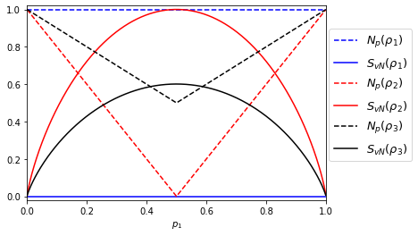

```python
def jogo():
    p1 = np.arange(10**-6,1,0.001);
    Np1 = p1-p1+1; S1 = 0*p1
    Np2 = np.maximum(2*p1-1,2*(1-p1)-1);
    S2 = -p1*np.log2(p1)-(1-p1)*np.log2(1-p1)
    Np3 = np.maximum(p1,1-p1)
    l1 = (1+np.sqrt(1-2*p1*(1-p1)))/2;
    S3 = -l1*np.log2(l1)-(1-l1)*np.log2(1-l1)
    plt.plot(p1,Np1,'--',color='blue');
    plt.plot(p1,S1,color='blue')
    plt.plot(p1,Np2,'--',color='red');
    plt.plot(p1,S2,color='red')
    plt.plot(p1,Np3,'--',color='black');
    plt.plot(p1,S3,color='black')
    plt.legend((r'$N_{p}(\rho_{1})$',r'$S_{vN}(\rho_{1})$',
                r'$N_{p}(\rho_{2})$',r'$S_{vN}(\rho_{2})$',
               r'$N_{p}(\rho_{3})$',r'$S_{vN}(\rho_{3})$'),
               loc=(1.01,0.2), fontsize=13)
    plt.xlabel(r'$p_{1}$'); plt.xlim(0,1);
    plt.ylim(-0.02,1.02)
    plt.show()
jogo()
```

## Entropia de Wigner-Yanase (EWY)

Enquanto as EL e EN quantificam incerteza clássica, a EWY quantifica incerteza quântica em relação a um observável $O$ para um sistema no estado $\rho$: \begin{align} S_{wy}(O|\rho) & := -\frac{1}{2}\mathrm{Tr}\left([\sqrt{\rho},O]^{2}\right) \\ &= -\frac{1}{2}\mathrm{Tr}\left((\sqrt{\rho}O-O\sqrt{\rho})^{2}\right) = -\frac{1}{2}\mathrm{Tr}\left( (\sqrt{\rho}O-O\sqrt{\rho})(\sqrt{\rho}O-O\sqrt{\rho}) \right) \\ & = -\frac{1}{2}\mathrm{Tr}\left( \sqrt{\rho}O\sqrt{\rho}O -O\sqrt{\rho}\sqrt{\rho}O - \sqrt{\rho}OO\sqrt{\rho} +O\sqrt{\rho}O\sqrt{\rho} \right) \\ & = -\frac{1}{2}\left( \mathrm{Tr}(\sqrt{\rho}O\sqrt{\rho}O) - \mathrm{Tr}(O\rho O) - \mathrm{Tr}(\sqrt{\rho}O^{2}\sqrt{\rho}) + \mathrm{Tr}(O\sqrt{\rho}O\sqrt{\rho}) \right) \\ & = \mathrm{Tr}(\rho O^{2}) - \mathrm{Tr}(\sqrt{\rho}O\sqrt{\rho}O) \\ & = \langle O^{2}\rangle_{\rho} - \mathrm{Tr}\left((O\sqrt{\rho})^{2}\right). \end{align}

OBS. Note que se $\rho$ e $O$ comutam, a EWY é nula, mesmo que nossa incerteza clássica sobre o estado do sistema seja positiva.

OBS. Se o estado for puro, i.e., se $\rho=|\psi\rangle\langle\psi|$, a entropia de Wigner-Yanase coincide com a variância $E_{wy}(|\psi\rangle)=Var_{\psi}(O)$.

### Exemplo

*OBS:* O comprimento do vetor de Bloch não muda por transformações unitárias. Para verificar essa informação, considera $\rho'=U\rho U^{\dagger}$. Para sistemas de 2 níveis \begin{align} P(\rho) & = \mathrm{Tr} \left(\frac{1}{2}\left(\sigma_{0} + \sum_{j=1}^{3}r_{j}\sigma_{j}\right)\frac{1}{2}\left(\sigma_{0} + \sum_{k=1}^{3}r_{k}\sigma_{k}\right)\right) \\ & = \frac{1}{4}\mathrm{Tr}\left(\sigma_{0} + 2\sum_{j=1}^{3}r_{j}\sigma_{j} + \sum_{j,k=1}^{3}r_{j}r_{k}\sigma_{j}\sigma_{k} \right) \\ & = \frac{1}{4}\left(2 + 0 + \sum_{j,k=1}^{3}r_{j}r_{k}\mathrm{Tr}(\sigma_{j}\sigma_{k}) \right) = \frac{1}{4}\left(2 + \sum_{j,k=1}^{3}r_{j}r_{k}2\delta_{jk} \right) \\ & = \frac{1}{2}\left(1 + r^{2} \right). \end{align} Pela invariância da função traço sob transformações unitárias (mudança de base), teremos que \begin{align} P(\rho') & = \frac{1}{2}\left(1 + r'^{2} \right) = \mathrm{Tr}(U\rho U^{\dagger}U\rho U^{\dagger}) = \mathrm{Tr}(U\rho\rho U^{\dagger}) \\ & = \mathrm{Tr}(\rho^{2}) = P(\rho). \end{align} Portanto $r'=r$. Ou seja, tranformações unitárias somente giram o vetor de Bloch em $\mathbb{R}^{3}$.

Vamos calcular aquelas três entropias para o estado geral de um sistema de 2 níveis mostrado acima. Da expressão para a pureza vem que \begin{equation} S_{L}(\rho) = \frac{1-r^{2}}{2}. \end{equation} Já, dos autovalores de $\rho$, a EN fica \begin{align} S_{vN}(\rho) & = -\frac{1+r}{2}\log_{2}\frac{1+r}{2} - \frac{1-r}{2}\log_{2}\frac{1-r}{2} \\ & = \vdots \\ & = 1 - 2^{-1}[(1+r)\log_{2}(1+r) + (1-r)\log_{2}(1-r)]. \end{align}

Para obter $S_{wy}$ consideraremos como observável $\sigma_{z}$. Nesse caso, como $\sigma_{z}^{2}=\sigma_{0}$, fazendo $\rho=r_{+}|r_{+}\rangle\langle r_{+}|+r_{-}|r_{-}\rangle\langle r_{-}|$ com $r_{\pm}=(1\pm r)/2$ e $|r_{+}\rangle = \cos(\theta/2)|z_{+}\rangle + e^{i\phi}\sin(\theta/2)|z_{-}\rangle$ e $|r_{-}\rangle = \sin(\theta/2)|z_{+}\rangle - e^{i\phi}\cos(\theta/2)|z_{-}\rangle$. Assim, usando $\sigma_{z}|r_{+}\rangle = \cos(\theta/2)|z_{+}\rangle - e^{i\phi}\sin(\theta/2)|z_{-}\rangle$, $\sigma_{z}|r_{-}\rangle=\sin(\theta/2)|z_{+}\rangle + e^{i\phi}\cos(\theta/2)|z_{-}\rangle$ e $\mathrm{Tr}(A|\psi\rangle\langle\psi|)=\langle\psi|A|\psi\rangle$ obteremos \begin{align} S_{wy}(\sigma_{z}|\rho) & = \mathrm{Tr}(\rho) - \mathrm{Tr}\left((\sigma_{z}\sqrt{\rho})^{2}\right) \\ & = 1 - \mathrm{Tr}\left((\sigma_{z}(\sqrt{r_{+}}|r_{+}\rangle\langle r_{+}|+\sqrt{r_{-}}|r_{-}\rangle\langle r_{-}|))^{2}\right) \\ & = 1 - \mathrm{Tr}(\sqrt{r_{+}}\sigma_{z}|r_{+}\rangle\langle r_{+}| + \sqrt{r_{-}}\sigma_{z}|r_{-}\rangle\langle r_{-}|)^{2} \\ & = 1 - \mathrm{Tr}\left(r_{+}\sigma_{z}|r_{+}\rangle\langle r_{+}|\sigma_{z}|r_{+}\rangle\langle r_{+}| + \sqrt{r_{+}r_{-}}\sigma_{z}|r_{+}\rangle\langle r_{+}|\sigma_{z}|r_{-}\rangle\langle r_{-}| + \sqrt{r_{+}r_{-}}\sigma_{z}|r_{-}\rangle\langle r_{-}|\sigma_{z}|r_{+}\rangle\langle r_{+}| + r_{-}\sigma_{z}|r_{-}\rangle\langle r_{-}|\sigma_{z}|r_{-}\rangle\langle r_{-}| \right) \\ & = 1 - r_{+}\langle r_{+}|\sigma_{z}|r_{+}\rangle^{2} - 2\sqrt{r_{+}r_{-}}|\langle r_{-}|\sigma_{z}|r_{+}\rangle|^{2} - r_{-}\langle r_{-}|\sigma_{z}|r_{-}\rangle^{2} \\ & = 1 - r_{+}(\cos^{2}(\theta/2)-\sin^{2}(\theta/2))^{2} - 2\sqrt{r_{+}r_{-}}|2\sin(\theta/2)\cos(\theta/2)|^{2} - r_{-}(\sin^{2}(\theta/2)-\cos^{2}(\theta/2))^{2} \\ & = 1 - 2^{-1}(1+r)\cos^{2}\theta - \sqrt{1-r^{2}}\sin^{2}\theta - 2^{-1}(1-r)\cos^{2}\theta = 1 - \cos^{2}\theta - \sqrt{1-r^{2}}\sin^{2}\theta \\ & = (1-\sqrt{1-r^{2}})\sin^{2}\theta. \end{align}

```python
def entropies(n):
    th = n*np.pi/8; N = 100; dr = (1.01-0)/N
    rv = np.zeros(N); P = np.zeros(N); Sl = np.zeros(N)
    Sn = np.zeros(N);
    Swy = np.zeros(N); #th = entropies(th)
    r = -dr
    for j in range(0,N):
        r += dr; rv[j] = r; P[j] = (1+r**2)/2; Sl[j] = 1-P[j]
        Sn[j] = 1-(1/2)*((1+r)*log(1+r,2) + (1-r)*log(1-r,2));
        Swy[j] = (1-sqrt(1-r**2))*(sin(th))**2
    plt.xlabel(r'$r$'); plt.plot(rv, P, label=r'$P$');
    plt.plot(rv, Sl, label=r'$S_{L}$')
    plt.plot(rv, Sn, label=r'$S_{vN}$');
    plt.plot(rv, Swy, label=r'$S_{WY}(\theta=\pi/4)$')
    axes = plt.gca(); axes.set_xlim([0,1]);
    axes.set_ylim([-0.1,1.1])
    plt.legend(bbox_to_anchor=(1.05, 1),
               loc='upper left', borderaxespad=0.);
    plt.show()
```

```python
interactive(entropies, n=(0,8))
```

```
interactive(children=(IntSlider(value=4, description='n', max=8), Output()), _dom_classes=('widget-interact',)…
```

# Exercícios

1. Para um sistema físico de dimensão $d=\dim\mathcal{H}$ e ensembles $\rho\equiv\{|\psi_{j}\rangle\}_{j=1}^{n}$, forneça exemplos de ensembles com $n<d$, $n=d$ e $n>d$.
2. Para sistemas de dois níveis, forneça dois ensembles "diferentes" que levam ao mesmo estado $\rho=\sigma_{0}/2$.
3. Verifique que o valor médio de um observável $O$, para um sistema preparado no estado $\rho\equiv\{|\psi_{j}\rangle,p_{j}\}_{j=1}^{n}$, pode ser escrito como: \begin{equation} \langle O\rangle_{\rho} = \mathrm{Tr}(\rho O). \end{equation}
4. Considere que $|z_{+}\rangle$ é preparado com probabilidade $3/4$ e que $|y_{+}\rangle$ é preparado como probabilidade $1/4$. Obtenha a matriz densidade, na base padrão, para o operador densidade que representa esse ensemble. Use esse operador para calcular as probabilidades para a componente de spin na direção $\hat{n} = (1/\sqrt{2},0,1/\sqrt{2})$.
5. Verifique que os autovalores de $\rho=\frac{1}{2}\begin{bmatrix} 1+r_{3} & r_{1}-i r_{2} \\ r_{1}+i r_{2} & 1-r_{3} \end{bmatrix}$ são $(1\pm r)/2$, com $r = \sqrt{\sum_{j=1}^{3}r_{j}^{2}}$.
6. Os autovalores das matrizes de Pauli $\{\sigma_{j}\}_{j=1}^{3}$ são $\pm 1$. Mostre que $\langle\sigma_{j}\rangle_{\rho}\in[-1,+1]$ para qualquer estado $\rho$.
7. Para o Hamiltoniano $H=-2^{-1}\hbar\omega\sigma_{x}$ e o estado inicial $\rho_{0}=\begin{bmatrix}\rho_{1,1}(0)&\rho_{1,2}(0)\\\rho_{2,1}(0)&\rho_{2,2}(0)\end{bmatrix}$, resolva a equação de von Neumann para obter o estado evoluído $\rho_{t}=\begin{bmatrix}\rho_{1,1}(t)&\rho_{1,2}(t)\\\rho_{2,1}(t)&\rho_{2,2}(t)\end{bmatrix}=\begin{bmatrix}\rho_{1,1}(t)&\Re(\rho_{1,2}(t))+i\Im(\rho_{1,2}(t))\\\Re(\rho_{1,2}(t))-i\Im(\rho_{1,2}(t))&1-\rho_{1,1}(t)\end{bmatrix}$.
8. Obtenha o estado térmico de um spin 1/2 com Hamiltoniano $H=-(\hbar\omega/2)\sigma_{y}$. Calcule a energia média e entropia desse sistema. Grafique $Z$, $\langle H\rangle/\hbar\omega$, e $S_{th}/k_{B}\ln 2$ como função de $\beta\hbar\omega$.
9. Considere uma fonte de informação que emite os símbolos $\{X_{1},X_{2},X_{3},X_{4}\}$ com probabilidades respectivas $\{1/2,1/4,1/8,1/8\}$. Verifique que a entropia de Shannon dessa variável aleatória é $H(X)=7/4$.  
   OBS. Podemos, claro, codificar esses símbols usando dois bits de informação através da representação $X_{1}\rightarrow 00, X_{2}\rightarrow 01, X_{3}\rightarrow 10, X_{4}\rightarrow 11$. É interessante notar que se codificarmos símbolos mais prováveis usando menos bits e símbolos menos prováveis usando mais bits, podemos diminuir, em média, a quantidade de bits necessários para armazenar essa fonte. Consideremos a codificação $X_{1}\rightarrow 0, X_{2}\rightarrow 10, X_{3}\rightarrow 110, X_{4}\rightarrow 111$. O número médio de bits necessários para armazer uma sequência de símbolos é nesse caso: \begin{equation} 1\frac{1}{2}+2\frac{1}{4}+3\frac{1}{8}+3\frac{1}{8} = \frac{7}{4} = 1.75 \text{ bits por símbolo.} \end{equation}
10. Verifique que $S_{vN}(\mathbb{I}/d) = \log_{2}d$ e que $S_{vN}(|\psi\rangle\langle\psi|)=0$.
11. Verifique que a entropia de von Neumann é invariante por mudança de base, i.e., verifique que $S_{vN}(U\rho U^{\dagger})=S_{vN}(\rho)$ para $UU^{\dagger}=U^{\dagger}U=\mathbb{I}$.
12. Verifique que a representação matricial do operador densidade $\rho_{3}=p_{1}|x_{+}\rangle\langle x_{+}|+p_{2}|z_{+}\rangle\langle z_{+}|$ na base $\{|z_{+}\rangle,|z_{-}\rangle\}$ é $\rho_{3}\doteq\begin{bmatrix}-p_{1}/2+1 & p_{1}/2 \\ p_{1}/2&p_{1}/2\end{bmatrix}$. Diagonalizando essa matriz, obtenha a entropia de von Neumann $S_{vN}(\rho_{3})=-\lambda_{1}\log_{2}(\lambda_{1})-(1-\lambda_{1})\log_{2}(1-\lambda_{1})$ com $\lambda_{1}=(1+\sqrt{1-2p_{1}(1-p_{1})})/2$.
13. Verifique que se $[\rho,O]=0$ então $S_{wy}(O|\rho)=0$.
14. Verifique que para estados puros, $\rho=|\psi\rangle\langle\psi|$, a entropia de Wigner-Yanase coincide com a variância: $S_{wy}(O|\rho)=\mathrm{Var}(O)_{\psi}$.